# “Project 2: bipartite graph, possible exercise solutions”

Jennifer Brown

2024-01-01

1. Make a grid of help lines with the lower left corner of the rectangular grid at $(-2,-2)$ and the upper right corner at $(2,2)$. Using the $\verb|vertex|$ style developed in this project (modified if you like), put a dot at each non-origin intersection point of the help lines. Put a noticeably different sort of dot at the origin.

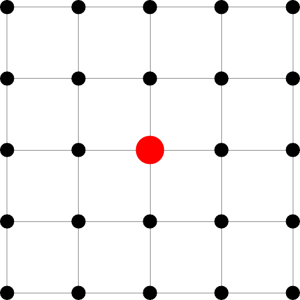

```latex
\begin{tikzpicture}

% vertex style for dots
\tikzstyle{vertex}=[circle, fill, inner sep=2pt]

% grid lines
\draw[help lines] (-2,-2) grid (2,2);

% bottom row of dots (with y=-2)
\node [vertex] at (-2,-2) {};
\node [vertex] at (-1,-2) {};
\node [vertex] at (0,-2) {};
\node [vertex] at (1,-2) {};
\node [vertex] at (2,-2) {};

% next row up of dots (with y=-1)
\node [vertex] at (-2,-1) {};
\node [vertex] at (-1,-1) {};
\node [vertex] at (0,-1) {};
\node [vertex] at (1,-1) {};
\node [vertex] at (2,-1) {};

% middle row up of dots (with y=0)
\node [vertex] at (-2,0) {};
\node [vertex] at (-1,0) {};
% big red dot at (0,0)
\node [circle, red, fill, inner sep=4pt] at (0,0) {};
\node [vertex] at (1,0) {};
\node [vertex] at (2,0) {};

% next row up of dots (with y=1)
\node [vertex] at (-2,1) {};
\node [vertex] at (-1,1) {};
\node [vertex] at (0,1) {};
\node [vertex] at (1,1) {};
\node [vertex] at (2,1) {};

% top row up of dots (with y=2)
\node [vertex] at (-2,2) {};
\node [vertex] at (-1,2) {};
\node [vertex] at (0,2) {};
\node [vertex] at (1,2) {};
\node [vertex] at (2,2) {};

\end{tikzpicture}
```

2. Modify the final graph picture in this project so that there is an additional edge from $a$ to $f$, but no edge from $b$ to $e$.

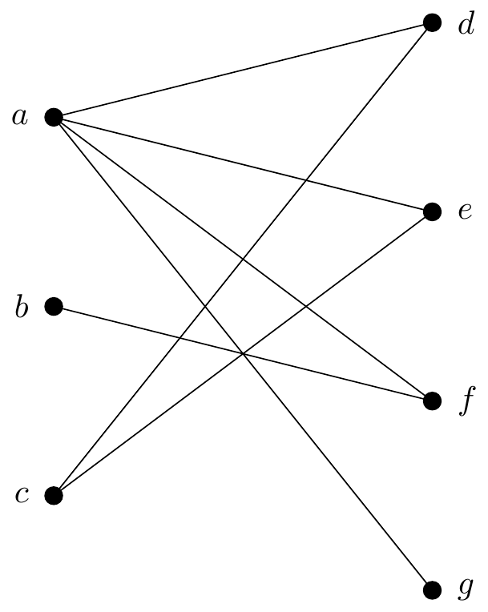

```latex
\begin{tikzpicture}

% vertex style to be used at vertex nodes
\tikzstyle{vertex}=[circle, fill, inner sep=2pt]

% help lines (comment out when done)
% \draw [help lines] (-1,-4) grid (5,4);

% edges from vertex a
\draw (0,2) -- (4,3);
\draw (0,2) -- (4,1);
\draw (0,2) -- (4,-3);
\draw (0,2) -- (4,-1);

% edges from vertex b
\draw (0,0) -- (4,-1);

% edges from vertex c
\draw (0,-2) -- (4,3);
\draw (0,-2) -- (4,1);

% dot at vertex a
\node [vertex] at (0,2) {};
% label at vertex a
\node [left=4pt] at (0,2) {$a$};

% dot at vertex b
\node [vertex] at (0,0) {};
% label at vertex b
\node [left=4pt] at (0,0) {$b$};

% dot at vertex c
\node [vertex] at (0,-2) {};
% label at vertex a
\node [left=4pt] at (0,-2) {$c$};

% dot at vertex d
\node [vertex] at (4,3) {};
% label at vertex d
\node [right=4pt] at (4,3) {$d$};

% dot at vertex e
\node [vertex] at (4,1) {};
% label at vertex e
\node [right=4pt] at (4,1) {$e$};

% dot at vertex f
\node [vertex] at (4,-1) {};
% label at vertex f
\node [right=4pt] at (4,-1) {$f$};

% dot at vertex g
\node [vertex] at (4,-3) {};
% label at vertex g
\node [right=4pt] at (4,-3) {$g$};

\end{tikzpicture}
```

3. Modify the final graph picture in this project by adding an additional vertex $h$ at $(4,-5)$, and give it edges to $c$ and $b$.

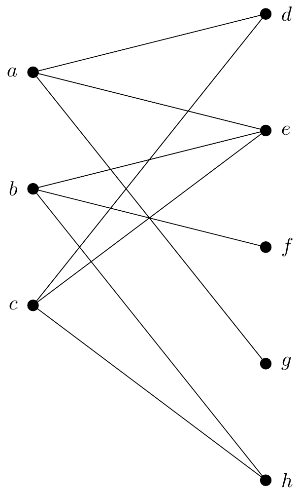

```latex
\begin{tikzpicture}

% vertex style to be used at vertex nodes
\tikzstyle{vertex}=[circle, fill, inner sep=2pt]

% help lines (comment out when done)
% \draw [help lines] (-1,-4) grid (5,4);

% edges from vertex a
\draw (0,2) -- (4,3);
\draw (0,2) -- (4,1);
\draw (0,2) -- (4,-3);

% edges from vertex b
\draw (0,0) -- (4,1);
\draw (0,0) -- (4,-1);
\draw (0,0) -- (4,-5);

% edges from vertex c
\draw (0,-2) -- (4,3);
\draw (0,-2) -- (4,1);
\draw (0,-2) -- (4,-5);

% dot at vertex a
\node [vertex] at (0,2) {};
% label at vertex a
\node [left=4pt] at (0,2) {$a$};

% dot at vertex b
\node [vertex] at (0,0) {};
% label at vertex b
\node [left=4pt] at (0,0) {$b$};

% dot at vertex c
\node [vertex] at (0,-2) {};
% label at vertex a
\node [left=4pt] at (0,-2) {$c$};

% dot at vertex d
\node [vertex] at (4,3) {};
% label at vertex d
\node [right=4pt] at (4,3) {$d$};

% dot at vertex e
\node [vertex] at (4,1) {};
% label at vertex e
\node [right=4pt] at (4,1) {$e$};

% dot at vertex f
\node [vertex] at (4,-1) {};
% label at vertex f
\node [right=4pt] at (4,-1) {$f$};

% dot at vertex g
\node [vertex] at (4,-3) {};
% label at vertex g
\node [right=4pt] at (4,-3) {$g$};

% dot at vertex h
\node [vertex] at (4,-5) {};
% label at vertex h
\node [right=4pt] at (4,-5) {$h$};

\end{tikzpicture}
```

4. Modify the final graph picture in this project by defining and using a new vertex style, called $\verb|vertex2|$, that makes dots that are about half the size as the ones in the $\verb|vertex|$ style and are also green. (If you’d like to use something fancier than $\verb|green|$, see the [Using colors in LaTeX](https://www.overleaf.com/learn/latex/Using_colors_in_LaTeX) page in the Overleaf help documentation for a list of available $\verb|xcolor|$ colors. Be sure you’ve loaded the appropriate $\verb|xcolor|$ option before loading Ti*k*z in your preamble.) You may want to adjust the spacing between the labels and the vertices too.

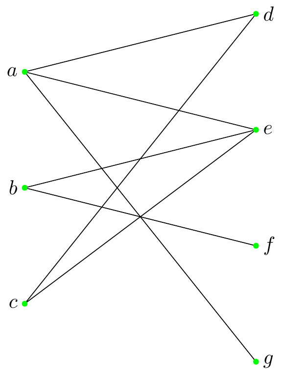

```latex
\begin{tikzpicture}

% vertex style to be used at vertex nodes
\tikzstyle{vertex2}=[circle, fill=green, inner sep=1pt]

% help lines (comment out when done)
% \draw [help lines] (-1,-4) grid (5,4);

% edges from vertex a
\draw (0,2) -- (4,3);
\draw (0,2) -- (4,1);
\draw (0,2) -- (4,-3);

% edges from vertex b
\draw (0,0) -- (4,1);
\draw (0,0) -- (4,-1);

% edges from vertex c
\draw (0,-2) -- (4,3);
\draw (0,-2) -- (4,1);

% dot at vertex a
\node [vertex2] at (0,2) {};
% label at vertex a
\node [left] at (0,2) {$a$};

% dot at vertex b
\node [vertex2] at (0,0) {};
% label at vertex b
\node [left] at (0,0) {$b$};

% dot at vertex c
\node [vertex2] at (0,-2) {};
% label at vertex a
\node [left] at (0,-2) {$c$};

% dot at vertex d
\node [vertex2] at (4,3) {};
% label at vertex d
\node [right] at (4,3) {$d$};

% dot at vertex e
\node [vertex2] at (4,1) {};
% label at vertex e
\node [right] at (4,1) {$e$};

% dot at vertex f
\node [vertex2] at (4,-1) {};
% label at vertex f
\node [right] at (4,-1) {$f$};

% dot at vertex g
\node [vertex2] at (4,-3) {};
% label at vertex g
\node [right] at (4,-3) {$g$};

\end{tikzpicture}
```

5. Draw a picture of $K_{3,3}$, the complete bipartite graph from 3 vertices to 3 vertices, using ingredients from the code in the block for our final graph picture in this project.

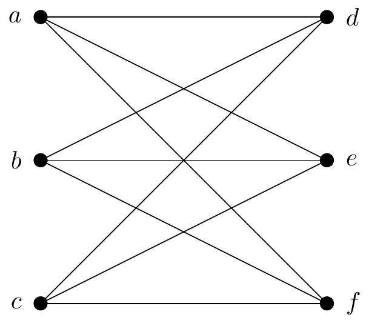

```latex
\begin{tikzpicture}

% vertex style to be used at vertex nodes
\tikzstyle{vertex}=[circle, fill, inner sep=2pt]

% help lines (comment out when done)
% \draw [help lines] (-1,-3) grid (5,3);

% edges from vertex a
\draw (0,2) -- (4,2);
\draw (0,2) -- (4,0);
\draw (0,2) -- (4,-2);

% edges from vertex b
\draw (0,0) -- (4,2);
\draw (0,0) -- (4,0);
\draw (0,0) -- (4,-2);

% edges from vertex c
\draw (0,-2) -- (4,2);
\draw (0,-2) -- (4,0);
\draw (0,-2) -- (4,-2);

% dot at vertex a
\node [vertex] at (0,2) {};
% label at vertex a
\node [left=4pt] at (0,2) {$a$};

% dot at vertex b
\node [vertex] at (0,0) {};
% label at vertex b
\node [left=4pt] at (0,0) {$b$};

% dot at vertex c
\node [vertex] at (0,-2) {};
% label at vertex a
\node [left=4pt] at (0,-2) {$c$};

% dot at vertex d
\node [vertex] at (4,2) {};
% label at vertex d
\node [right=4pt] at (4,2) {$d$};

% dot at vertex e
\node [vertex] at (4,0) {};
% label at vertex e
\node [right=4pt] at (4,0) {$e$};

% dot at vertex f
\node [vertex] at (4,-2) {};
% label at vertex f
\node [right=4pt] at (4,-2) {$f$};

\end{tikzpicture}
```

The content of this site is licensed under the [Creative Commons Attribution 4.0 International License.](https://creativecommons.org/licenses/by/4.0/)